# Easter's homework

In this notebook, I report the activities agreed at ML4NP meeting on 8 April 2020. The activities are the following:

1. Analyse what are the **events** that survive at **ROI cut** and what are the events lost. **[Done]**
2. Check for **correspondance** between **energy lost** and **energy deposited** in CJ simulations. **[Done]**
3. Compare the energy distribution using a **symmetric OP map** to prove/disconfirm the eventual efficiency in changing the fiber placement. **[Done]**
4. Produce some **Ar39 toy simulation** with MC script by Mario Schwarz. **[Stopped]**

The results of the above activities are:

```python
import pandas as pd
import os
import matplotlib.pyplot as plt
import numpy as np
plt.rcParams['figure.figsize'] = [25, 15]
plt.rcParams.update({'font.size': 18})
```

## Impact of ROI cut on simulated events

In the last-meeting presentation (*slide 3*), I reported `10594` events in ROI and only `6670` events detected. We aim to address the following questions:

- What are the event lost in the detection?
- Why there is only a ~60% efficiency?

First of all, I explain the previous data:

- *events in ROI* := number of events with at least 1 (non-zero) deposition in ROI among the 2e6 muon simulated by CJ.
- *events detected* := number of events with at least 1 OP detected using Neil's Map and Yield=40 OP/KeV.

```python
# Reproduce the result of last-meeting presentation
dir_in = os.path.join("..", "Data", "cutROI")
new_file = "output2eROI_all_wt_ops.csv"    # Note: This file uses only Internal Map
columns = ['PID', 'energydeposition', 'x', 'y', 'z', 'time', 'eventnumber', 'creatorprocess', 'OPs']

light_yield = 40    # number of photons per KeV
df = pd.read_csv(os.path.join(dir_in, new_file), index_col=False)[columns]
df = df[df.energydeposition>0]

# Add fields to filter detected events and see energy detected
df["OPdetected"] = df.energydeposition * light_yield * df.OPs  # OP Detected = Edep * LYield * DetEff
df["energydetected"] = df.OPdetected / light_yield             # Energy Detected = OP Detected / LYield
df["dist_origin"] = (df.x**2 + df.y**2 + df.z**2)**.5          # Euclidean distance from origin

print("[Info] Number of distinct events: {}".format(df.eventnumber.nunique()))
print("[Info] Number of detected events: {}".format(df[df.OPdetected>0].eventnumber.nunique()))

# Preview of data loaded
df.head()
```

```
[Info] Number of distinct events: 10594
[Info] Number of detected events: 6670
```

|  | PID | energydeposition | x | y | z | time | eventnumber | creatorprocess | OPs | OPdetected | energydetected | dist_origin |
| --- | --- | --- | --- | --- | --- | --- | --- | --- | --- | --- | --- | --- |
| 2 | 22 | 3.20630 | 410.980 | 174.100 | -946.000 | 44.3455 | 210 | eBrem | 0.0 | 0.0 | 0.0 | 1046.007347 |
| 3 | 11 | 168.22100 | 411.045 | 174.073 | -946.066 | 44.3460 | 210 | phot | 0.0 | 0.0 | 0.0 | 1046.088083 |
| 4 | 11 | 3.54527 | 468.747 | 244.047 | -915.800 | 44.0266 | 210 | compt | 0.0 | 0.0 | 0.0 | 1057.342106 |
| 5 | 11 | 8.27316 | 491.863 | 275.561 | -885.021 | 43.8606 | 210 | compt | 0.0 | 0.0 | 0.0 | 1049.345151 |
| 7 | 11 | 179.84300 | 211.392 | -220.104 | -960.597 | 33.9918 | 466 | compt | 0.0 | 0.0 | 0.0 | 1007.908203 |

```
[Info] Selected entries of lost events: 203805
```

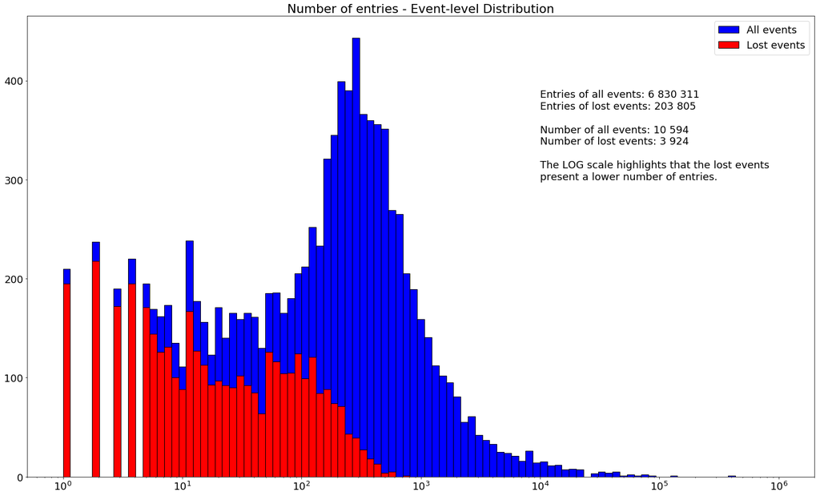

```python
# Analyse lost events
detectedevents_ids = df[df.OPdetected>0].eventnumber.unique()
df_lostevents = df[~(df.eventnumber.isin(detectedevents_ids))]
print("[Info] Selected entries of lost events: {}".format(len(df_lostevents)))

# Distribution of number of entries in lost events
logbins = np.logspace(0, 6, 100)    # Since there are lost events with very high number of entries
lostevents_nentries = df_lostevents.groupby("eventnumber").PID.count()
plt.hist(df.groupby("eventnumber").PID.count(), bins=logbins, color='b', edgecolor='k', label="All events")
plt.hist(lostevents_nentries, bins=logbins, color='r', edgecolor='k', label="Lost events")
plt.title("Number of entries - Event-level Distribution")
plt.xscale('log')
plt.text(10000, 300, "Entries of all events: 6 830 311\n" \
                     "Entries of lost events: 203 805\n\n" \
                     "Number of all events: 10 594\n" \
                     "Number of lost events: 3 924\n\n" \
                     "The LOG scale highlights that the lost events\n" \
                     "present a lower number of entries.")
plt.legend()
plt.show()
```

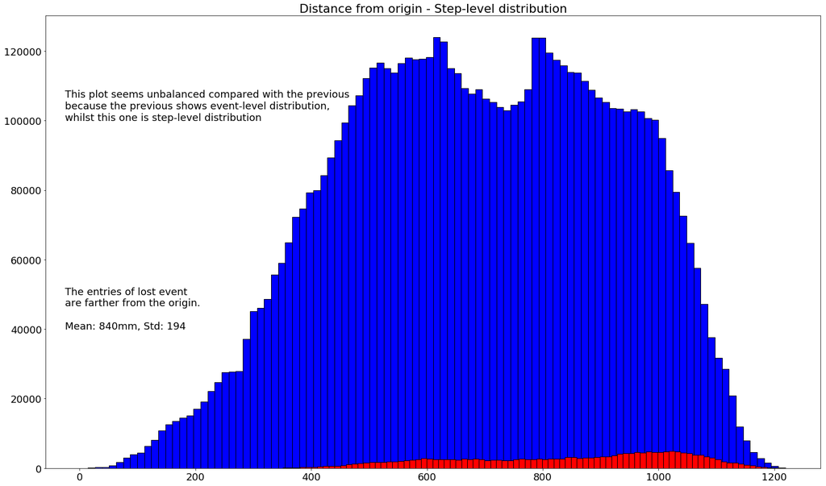

```python
# Analyse lost events w.r.t. coordinates
numbins = 100
lost_distance_stat = df_lostevents.dist_origin.describe()

plt.hist(df.dist_origin, bins=numbins, color='b', edgecolor='k', label="All entries")
plt.hist(df_lostevents.dist_origin, bins=numbins, color='r', edgecolor='k', label="Lost entries")
plt.title("Distance from origin - Step-level distribution")
plt.text(-25, 100000, "This plot seems unbalanced compared with the previous\n" \
                    "because the previous shows event-level distribution,\n" \
                    "whilst this one is step-level distribution")

plt.text(-25, 40000, "The entries of lost event\n"  \
                     "are farther from the origin.\n\n" \
                     "Mean: {:.0f}mm, Std: {:.0f}".format(lost_distance_stat.loc["mean"], lost_distance_stat.loc["std"]))
plt.show()
```

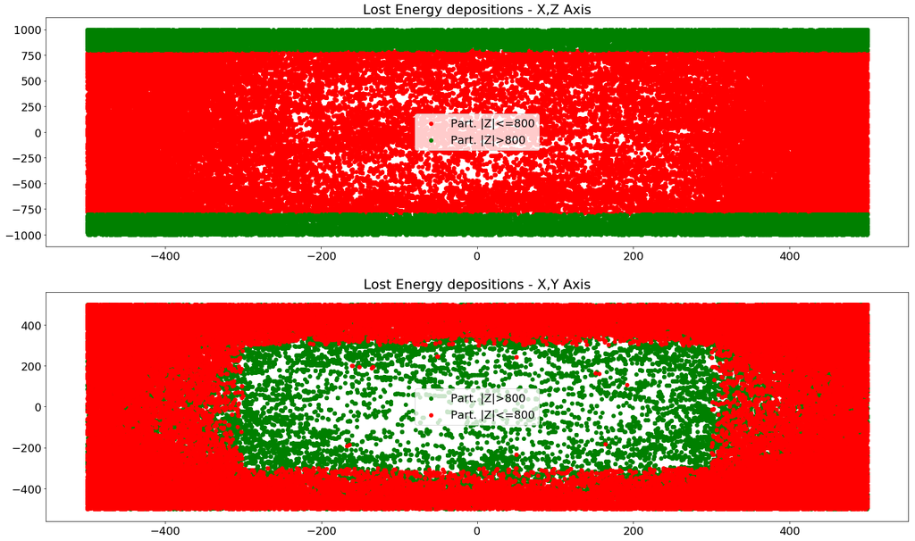

```python
# Partition the data w.r.t. Z axis (entries with x in [-800, +800] and others)
# Note the choice of partition corresponds to the end of fiber shroud
z_partition1 = df_lostevents[(df_lostevents.z >= -800) & (df_lostevents.z <= +800)]
z_partition2 = df_lostevents[(df_lostevents.z < -800) | (df_lostevents.z > +800)]

plt.subplot(2, 1, 1)
plt.scatter(z_partition1.x, z_partition1.z, color='r', label="Part. |Z|<=800")
plt.scatter(z_partition2.x, z_partition2.z, color='g', label="Part. |Z|>800")
plt.title("Lost Energy depositions - X,Z Axis")
plt.legend()

plt.subplot(2, 1, 2)
plt.scatter(z_partition2.x, z_partition2.y, color='g', label="Part. |Z|>800")
plt.scatter(z_partition1.x, z_partition1.y, color='r', label="Part. |Z|<=800")
plt.title("Lost Energy depositions - X,Y Axis")
plt.legend()

plt.show()
```

## Correspondance of energy lost and deposited

In the last week, we clarify how G4 handles energy depositions thanks to the emails with Luciano and CJ. I briefly summarize the terminology:

- *energy lost*: difference of primary-particle's kinetic energy in two simulation steps.
- *energy deposited*: amount energy locally deposited. It includes energy deposited in the current material (i.e. argon, in the case of muon simulations) by primary particle and secondaries that fall in the range-cut (and then, they are not created).

Having this in mind, we remark that by conservation of energy, the **sum** of **local energy depositions** with **kinetic energy of secondaries** correspond to the amount of **energy lost** by the primary particle.

Proving this from data is not easy because:

- **particles** move at **light speed** then considering time is not enough to filter the data,
- the **output scheme** has been **reduced** to match storage requirements, then useful fields such as initial position (x, y, z) have been removed.

Then, the **observed data** could present **wierd things**:

- The sum of kinetic energy of secondaries with local deposition is **far below the energy lost**. This is explained considering that the entries corresponds to energy deposition and not simulation steps, then the kinetic energy is not the original one but rather the one discounted a few steps later. Moreover, other secondaries could be produced that end outside the sensitive region and not being observable.
- The sum of kinetic energy of secondaries with local deposition is **above the energy lost**. This is explained by the counting of energies of other particles, not directly created by the primary in the current step but rather produced previously. Since they move fast and we don't have full simulation data, they become not distinguishable.

# Impact of Z-Symmetry on Neil's Map

Changing the placement of fibers shroud would affect the detection efficiency of OP production. In this section, we force the symmetry of detection efficiency reflecting the first half of Neil's map (Z>0) with respect to the origin. This reflection aims to reproduce the effect of unenrolling the fibers vertically, placing the SiPM modules on top and bottom of the shroud.

We aim to address the following questions:

1. The Neil's map is symmetric with respect to the Z-axis?
2. Reflecting the detection efficiency of the upper-half improves the overall detection efficiency?
3. From the previous result, what can we conclude on changing the fiber placement?

To answer this question, I produced 2 copies of Neil's Map in `csv` format. To do so, I've run a simple script that iterates over X, Y, Z coordinates with `5mm` increment. Looping over the bins, I collected the detection efficiency from the Map. The files are:

- `asNeil.csv`, it contains the same detection efficiency of Neil's Map.
- `reflectZAxis.csv`, it contains the detection efficiency of the bin (`x`, `y`, `|z|`), for all `x`, `y`, `z`.

```python
%reset
```

```
Once deleted, variables cannot be recovered. Proceed (y/[n])? y
```

```python
import pandas as pd
import os
import matplotlib.pyplot as plt
import numpy as np
plt.rcParams['figure.figsize'] = [25, 15]
plt.rcParams.update({'font.size': 18})
```

```python
# Load data of original map and symmetric map
dir_in = os.path.join("..", "Data", "root", "checkSymmetry")
current_mapfile = "asNeil.csv"
symmetric_mapfile = "reflectZAxis.csv"
columns = ["x", "y", "z", "detectionefficiency"]

current_map = pd.read_csv(os.path.join(dir_in, current_mapfile))[columns]
symmetric_map = pd.read_csv(os.path.join(dir_in, symmetric_mapfile))[columns]
```

```python
# Print statistics of detection efficiency distributions
pd.DataFrame([current_map.detectionefficiency.describe(), symmetric_map.detectionefficiency.describe()],
            index=["current", "symmetric"])
```

|  | count | mean | std | min | 25% | 50% | 75% | max |
| --- | --- | --- | --- | --- | --- | --- | --- | --- |
| current | 16000000.0 | 0.007402 | 0.012786 | 0.0 | 0.0 | 0.0 | 0.014 | 0.098 |
| symmetric | 16000000.0 | 0.006361 | 0.011041 | 0.0 | 0.0 | 0.0 | 0.012 | 0.076 |

The **symmetric map** results **less efficient**: both mean value and max value are lower. **Why?**

To answer this question, we plot the detection efficiency w.r.t. partitioning of each axis, meaning that we consider X>0 vs X<0, Y>0 vs Y<0, Z>0 vs Z<0. In particular, we expect to see significant difference only in the third case.

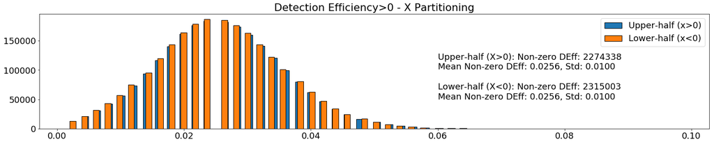

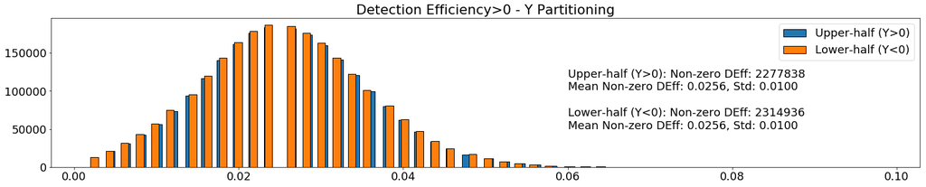

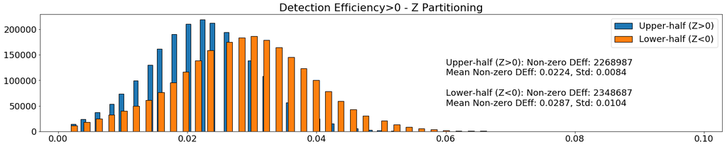

```python
xpos_map = current_map[(current_map.x>0) & (current_map.detectionefficiency>0)]
xneg_map = current_map[(current_map.x<0) & (current_map.detectionefficiency>0)]

xpos_map_stat = xpos_map.detectionefficiency.describe()
xneg_map_stat = xneg_map.detectionefficiency.describe()

plt.subplot(3, 1, 1)
bins = 100
plt.hist(xpos_map.detectionefficiency, bins=bins, label="Upper-half (x>0)", edgecolor='k')
plt.hist(xneg_map.detectionefficiency, bins=bins, label="Lower-half (x<0)", edgecolor='k')
plt.title("Detection Efficiency>0 - X Partitioning")
plt.text(.06, 50000, "Upper-half (X>0): Non-zero DEff: {:.0f}\n" \
                     "Mean Non-zero DEff: {:.4f}, Std: {:.4f}\n\n" \
                     "Lower-half (X<0): Non-zero DEff: {:.0f}\n" \
                     "Mean Non-zero DEff: {:.4f}, Std: {:.4f}".format(xpos_map_stat.loc["count"], xpos_map_stat.loc["mean"], xpos_map_stat.loc["std"],
                                                                      xneg_map_stat.loc["count"], xneg_map_stat.loc["mean"], xneg_map_stat.loc["std"]))
plt.legend()
plt.show()

ypos_map = current_map[(current_map.y>0) & (current_map.detectionefficiency>0)]
yneg_map = current_map[(current_map.y<0) & (current_map.detectionefficiency>0)]

ypos_map_stat = ypos_map.detectionefficiency.describe()
yneg_map_stat = yneg_map.detectionefficiency.describe()

plt.subplot(3, 1, 2)
bins = 100
plt.hist(xpos_map.detectionefficiency, bins=bins, label="Upper-half (Y>0)", edgecolor='k')
plt.hist(xneg_map.detectionefficiency, bins=bins, label="Lower-half (Y<0)", edgecolor='k')
plt.title("Detection Efficiency>0 - Y Partitioning")
plt.text(.06, 50000, "Upper-half (Y>0): Non-zero DEff: {:.0f}\n" \
                     "Mean Non-zero DEff: {:.4f}, Std: {:.4f}\n\n" \
                     "Lower-half (Y<0): Non-zero DEff: {:.0f}\n" \
                     "Mean Non-zero DEff: {:.4f}, Std: {:.4f}".format(ypos_map_stat.loc["count"], ypos_map_stat.loc["mean"], ypos_map_stat.loc["std"],
                                                                      yneg_map_stat.loc["count"], yneg_map_stat.loc["mean"], yneg_map_stat.loc["std"]))
plt.legend()
plt.show()

zpos_map = current_map[(current_map.z>0) & (current_map.detectionefficiency>0)]
zneg_map = current_map[(current_map.z<0) & (current_map.detectionefficiency>0)]

zpos_map_stat = zpos_map.detectionefficiency.describe()
zneg_map_stat = zneg_map.detectionefficiency.describe()

plt.subplot(3, 1, 3)
bins = 100
plt.hist(zpos_map.detectionefficiency, bins=bins, label="Upper-half (Z>0)", edgecolor='k')
plt.hist(zneg_map.detectionefficiency, bins=bins, label="Lower-half (Z<0)", edgecolor='k')
plt.title("Detection Efficiency>0 - Z Partitioning")
plt.text(.06, 50000, "Upper-half (Z>0): Non-zero DEff: {:.0f}\n" \
                     "Mean Non-zero DEff: {:.4f}, Std: {:.4f}\n\n" \
                     "Lower-half (Z<0): Non-zero DEff: {:.0f}\n" \
                     "Mean Non-zero DEff: {:.4f}, Std: {:.4f}".format(zpos_map_stat.loc["count"], zpos_map_stat.loc["mean"], zpos_map_stat.loc["std"],
                                                                      zneg_map_stat.loc["count"], zneg_map_stat.loc["mean"], zneg_map_stat.loc["std"]))
plt.legend()
plt.show()
```

As a consequence, the detection efficiency distribution averaged over the Z-axis results better in the current Neil's Map.

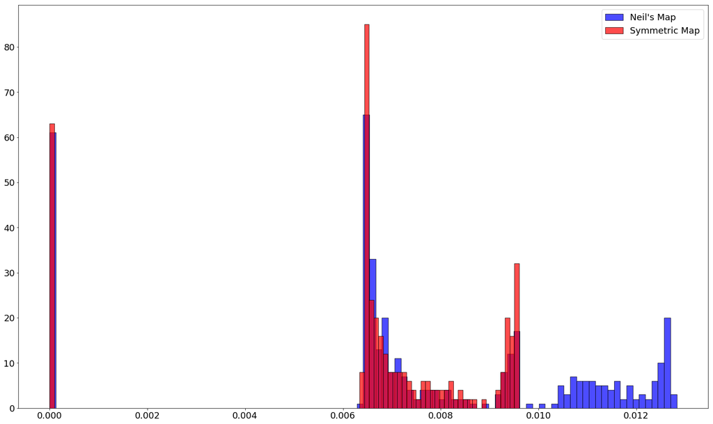

```python
# Detection efficiency distribution w.r.t. Z-axis
current_avg_deteff_z_axis = current_map.groupby("z").detectionefficiency.mean().reset_index()
symmetric_avg_deteff_z_axis = symmetric_map.groupby("z").detectionefficiency.mean().reset_index()
bins = 100
plt.hist(current_avg_deteff_z_axis.detectionefficiency, bins=bins,
         color='b', edgecolor='k', alpha=0.7, label="Neil's Map")
plt.hist(symmetric_avg_deteff_z_axis.detectionefficiency, bins=bins,
         color='r', edgecolor='k', alpha=0.7, label="Symmetric Map")
plt.legend()
plt.show()
```

### Results

From the previous plots, we remark the observations:

1. The current version of the **Neil's Map is asymetric** w.r.t. the **Z-Axis** and its **overall detection efficiency** is **higher** than the symmetric version, as illustrated in the **last figure**.
2. To confirm this claim, I've **compared** the detection efficiency of the Neil's Map **by partitioning each axis** in positive and negative values, as shown in the **first three figures**. There is **no significant difference** in **X, Y partitioning**, confirming the expected symmetry. However, the distributions on **Z partitioning** highlights **better performance** of the **lower half**, motivating the better performance of the asymmetric map.
3. These plots **disconfirm the expectations** about the symmetry derived by a symmetric fibers placement. This point deserves more attention to **verify the effectiveness** of the proposed change.